# Problem Set 2 - Answer key

Author

Yinjiao Zhong

Published

April 15, 2024

# 1 Question 1

## 1.1 A

**Answer**:

- **$H_0$ (Null hypothesis):** There is no significant difference in student’s heart rate when opening up R before and after taking EAS 538.
- **$H_A$ (Alternative hypothesis):** There is a significant difference in student’s heart rate when opening up R before and after taking EAS 538.

## 1.2 B

```r
# read data_q1
data1 <- read.csv("data_q1.csv")
head(data1, 3)
```

```
  student   when      rate
1       1 before  0.000000
2       2 before 12.444287
3       3 before  2.313573
```

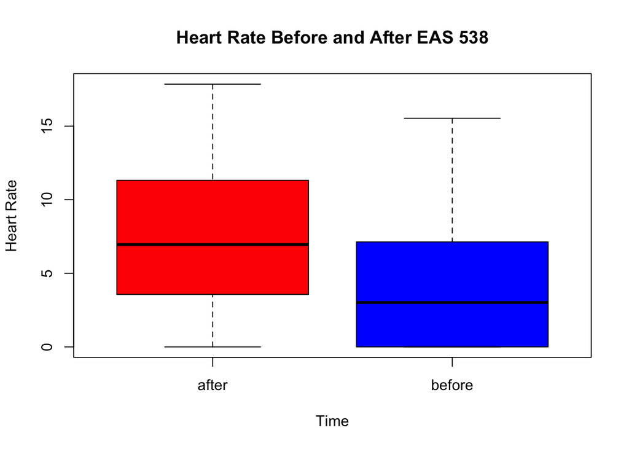

```r
# get box plot
boxplot(rate ~ when, data = data1, main = "Heart Rate Before and After EAS 538", xlab = "Time", ylab = "Heart Rate", col = c("red", "blue"))
```

**Answer**:

From the box plot, the mean of group “after” seems higher than the group “before”.

## 1.3 C

```r
# check if the data meets the assumption of normality
shapiro.test(data1$rate[data1$when == "before"])
```

```
    Shapiro-Wilk normality test

data:  data1$rate[data1$when == "before"]
W = 0.8827, p-value = 3.259e-05
```

```r
shapiro.test(data1$rate[data1$when == "after"])
```

```
    Shapiro-Wilk normality test

data:  data1$rate[data1$when == "after"]
W = 0.9563, p-value = 0.0311
```

```r
data1_1 <- data1 %>%
  pivot_wider(names_from=when, values_from=rate) %>%
  mutate(diff=after-before)
head(data1_1)
```

```
# A tibble: 6 × 4
  student before after    diff
    <int>  <dbl> <dbl>   <dbl>
1       1   0     5.14   5.14
2       2  12.4  17.2    4.72
3       3   2.31  0     -2.31
4       4   5.06  4.11  -0.949
5       5   2.08  9.49   7.41
6       6  15.5   0    -15.5
```

```r
# check if the data meets the assumption of normality after converting the data
dim(data1_1)
```

```
[1] 60  4
```

```r
shapiro.test(data1_1$diff)
```

```
    Shapiro-Wilk normality test

data:  data1_1$diff
W = 0.97299, p-value = 0.2038
```

**Answer**:

This data met continuous, and the sample is randomly selected from the population, then the observations also are independent. From shapiro test, the values are nearly normal or sample size is large enough, and because P-value = 0.2 > alpha = 0.05, we can not reject null hypothesis, it means that our data meet the assumption of normal distribution.

## 1.4 D

```r
# run paired t-test
t.test(data1_1$after, data1_1$before, paired = TRUE)
```

```
    Paired t-test

data:  data1_1$after and data1_1$before
t = 4.2214, df = 59, p-value = 8.502e-05
alternative hypothesis: true mean difference is not equal to 0
95 percent confidence interval:
 1.709315 4.790146
sample estimates:
mean difference
       3.249731
```

**Answer**:

According to paried t-test, because P-value = 8.502e-05 < alpha = 0.05, we can reject the null hypothesis, this means there is a significant difference in student’s heart rate when opening up R studio before and after taking EAS 538. After raking EAS 538 is significant different from one another, specifically, after raking EAS 538, the students’ heart rate increased by an average of about 3.25 beats per minute.

# 2 Question 2

## 2.1 A

```r
# read data
data2 = read.csv("data_q2.csv")
head(data2)
```

```
    type paid users comment like share
1  Photo    0   178       4   79    17
2 Status    0  1457       5  130    29
3  Photo    0   177       0   66    14
4  Photo    1  2211      58 1572   147
5  Photo    0   671      19  325    49
6 Status    0  1191       1  152    33
```

**Answer**:

Because we want to which factors are significantly associated with more shares of a post using multiple linear regression, but `paid` only included 0 and 1, so I’d like to choose other variables in my model.

```r
# check if the data meets the assumptions
# check correlation
cor1 <- cor(data2[, c("users", "comment", "like")])
print(cor1)
```

```
            users   comment      like
users   1.0000000 0.4139077 0.4827045
comment 0.4139077 1.0000000 0.6606773
like    0.4827045 0.6606773 1.0000000
```

```r
vif(lm(share~type+paid+users+comment+like, data=data2))
```

```
            GVIF Df GVIF^(1/(2*Df))
type    1.326783  3        1.048254
paid    1.024481  1        1.012166
users   1.741348  1        1.319601
comment 1.820190  1        1.349144
like    2.033110  1        1.425872
```

## 2.2 B

- **$H_0$ (Null hypothesis):**

There is no significant association between the factors and the more shares of a post.

- **$H_A$ (Alternative hypothesis):**

At least one of the factors is significantly associated with the more shares of a post.

## 2.3 C

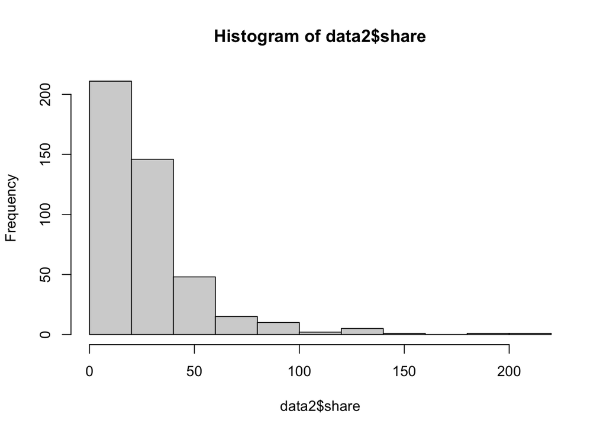

```r
# check the distribution of the dependent variable
hist(data2$share)
```

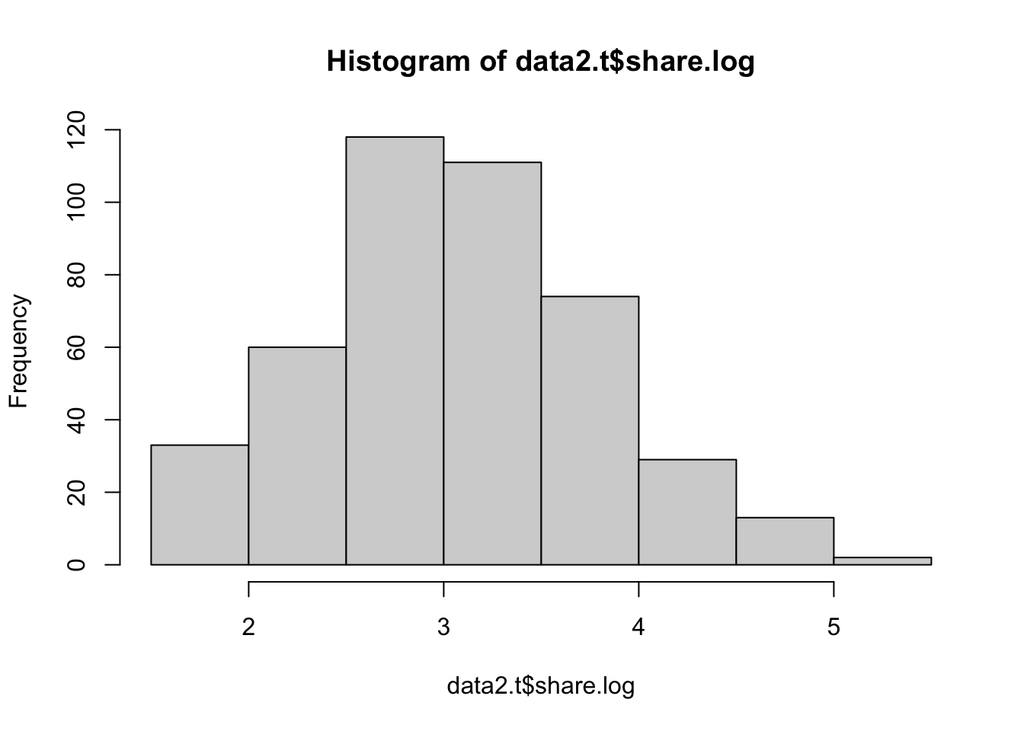

```r
data2.t <- data2 %>%
  mutate(share.log=log(share))
hist(data2.t$share.log)
```

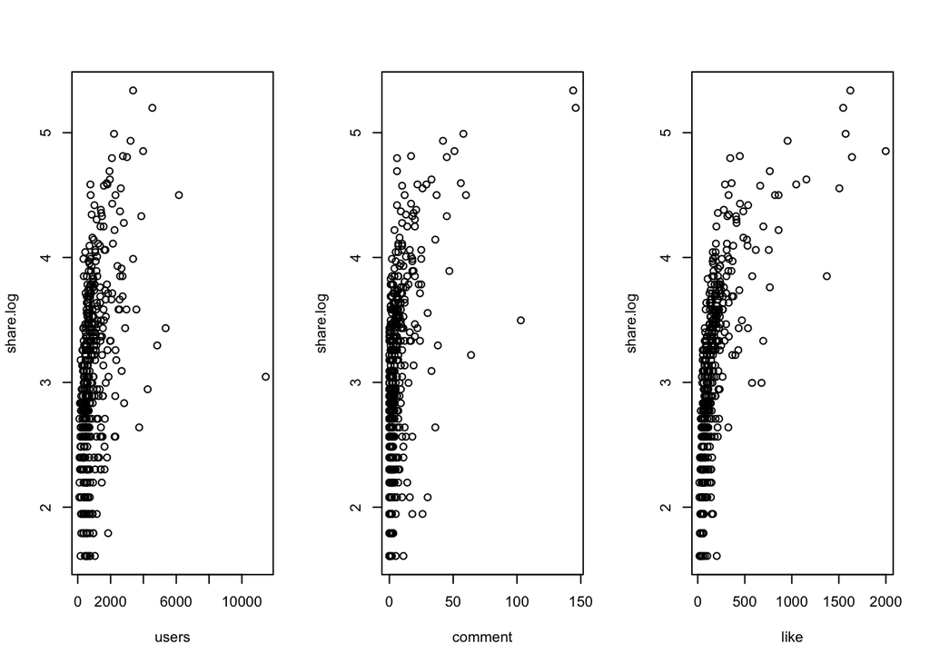

```r
# run linear model
lmod <- lm(share.log~users+comment+like+type+paid, data=data2.t)
# get linear relationship
par(mfrow=c(1,3))
plot(share.log~users, data=data2.t)
plot(share.log~comment, data=data2.t)
plot(share.log~like, data=data2.t)
```

```r
# check homoscedasticity
ncvTest(lmod)
```

```
Non-constant Variance Score Test
Variance formula: ~ fitted.values
Chisquare = 12.96021, Df = 1, p = 0.00031818
```

```r
# check residual normality
shapiro.test(residuals(lmod))
```

```
    Shapiro-Wilk normality test

data:  residuals(lmod)
W = 0.98876, p-value = 0.001874
```

**Answer**:

According to the plots, the linear relationship between the variables is met. Because in checking homoscedasticity, p-value = 0.0003 < alpha = 0.05, we can reject the ncvtest null hypothesis, which means the the assumption of homoscedasticity is not met. About checking the residual normality, the p-value = 0.001 < alpha = 0.05, so we can reject the shapiro test null hypothesis, which means the assumption of residual normality is not met.

## 2.4 D

```r
# run multiple linear regression model
summary(lmod)
```

```
Call:
lm(formula = share.log ~ users + comment + like + type + paid,
    data = data2.t)

Residuals:
     Min       1Q   Median       3Q      Max
-1.53962 -0.36000  0.03511  0.39555  1.28918

Coefficients:
              Estimate Std. Error t value Pr(>|t|)
(Intercept)  2.444e+00  1.340e-01  18.232  < 2e-16 ***
users        4.450e-05  3.583e-05   1.242  0.21498
comment      3.046e-03  2.496e-03   1.220  0.22301
like         1.712e-03  1.539e-04  11.124  < 2e-16 ***
typePhoto    2.542e-01  1.362e-01   1.867  0.06263 .
typeStatus   4.357e-01  1.672e-01   2.606  0.00949 **
typeVideo    6.682e-01  2.487e-01   2.687  0.00749 **
paid        -6.029e-02  5.860e-02  -1.029  0.30410
---
Signif. codes:  0 '***' 0.001 '**' 0.01 '*' 0.05 '.' 0.1 ' ' 1

Residual standard error: 0.5461 on 431 degrees of freedom
  (1 observation deleted due to missingness)
Multiple R-squared:  0.4409,    Adjusted R-squared:  0.4318
F-statistic: 48.55 on 7 and 431 DF,  p-value: < 2.2e-16
```

**Answer**:

-From the multiple linear regression result, because the P-value of `typeVideo`, `typeStatus` and `like` are less than alpha = 0.05, we could reject null hypothesis, which means `typeVideo`, `typeStatus` and `like` are significantly associated with the more shares of a post.

-The p-value of `users`, `comment`, `typePhoto` and `paid` are greater than alpha = 0.05, we can not reject null hypothesis, which means `users`, `comment`, `typePhoto` and `paid are not significantly associated with the more shares of a post.

-Regression coefficient of `typeVideo` is 6.682e-01 which means when `typeVideo` increase for every one-unit, the `share` of posts will increases by 6.682e-01 units.

-Regression coefficient of `like` is 1.712e-03, which means for every one-unit increase in the number of likes, the average `share` of posts increases by 1.712e-03 units.

## 2.5 E

The adjusted R-squared is 0.4318, which means the independent variables in the model explains 43.18% of the variation in the dependent variable (more shares of a post). Because the P-value of F-statistic is 2.2e-16 < alpha = 0.05, we can reject null hypothesis, which shows high significance. Therefore, the fit of my model is good.

# 3 Question 3

```r
# read in the data
data3 <- read.csv("data_q3.csv")
head(data3)
```

```
  Type Calories
1 beef 142.7532
2 beef 148.1573
3 beef 160.2559
4 beef 160.5317
5 beef 155.7573
6 beef 157.6918
```

## 3.1 A

- **$H_0$ (Null hypothesis):** There is no significant difference in the number of calories based on the different type of hot dog.
- **$H_A$ (Alternative hypothesis):** At least one of the types of hot dog differ in calories from others.

## 3.2 B

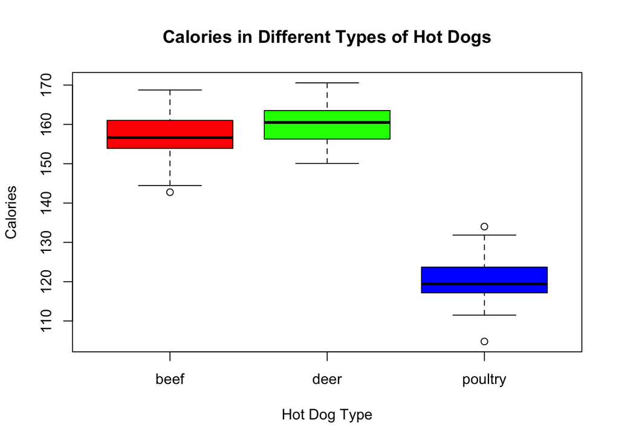

```r
# get a visual plot
boxplot(Calories ~ Type, data = data3, main = "Calories in Different Types of Hot Dogs", xlab = "Hot Dog Type", ylab = "Calories", col = c("red","green","blue"))
```

## 3.3 C

```r
# check Equal Variance
leveneTest(Calories~Type, data3, center=mean)
```

```
Levene's Test for Homogeneity of Variance (center = mean)
       Df F value Pr(>F)
group   2   0.923 0.3996
      147
```

```r
# check the assumption of normality distribution
beef <- filter(data3, Type=='beef')
deer <- filter(data3, Type=='deer')
poultry <- filter(data3, Type=='poultry')
dim(beef)
```

```
[1] 50  2
```

```r
dim(deer)
```

```
[1] 50  2
```

```r
dim(poultry)
```

```
[1] 50  2
```

```r
shapiro.test(beef$Calories)
```

```
    Shapiro-Wilk normality test

data:  beef$Calories
W = 0.97035, p-value = 0.2392
```

```r
shapiro.test(deer$Calories)
```

```
    Shapiro-Wilk normality test

data:  deer$Calories
W = 0.97698, p-value = 0.4329
```

```r
shapiro.test(poultry$Calories)
```

```
    Shapiro-Wilk normality test

data:  poultry$Calories
W = 0.97461, p-value = 0.3525
```

**Answer**:

This data met continuous, and the sample is randomly selected from the population, then the observations also are independent. From the shapiro test, P-value of all types are greater alpha = 0.05, so we can not reject null hypothesis, which means all types meet the assumption of normality. From leventest, P-values are greater alpha = 0.05, so we can not reject null hypothesis, which means they meet the assumption of homogeneity of variances.

## 3.4 D

```r
anova_result <- aov(Calories ~ Type, data = data3)
summary(anova_result)
```

```
             Df Sum Sq Mean Sq F value Pr(>F)
Type          2  48793   24397   763.3 <2e-16 ***
Residuals   147   4698      32
---
Signif. codes:  0 '***' 0.001 '**' 0.01 '*' 0.05 '.' 0.1 ' ' 1
```

```r
# run Tukey's HSD
tukey_result <- TukeyHSD(anova_result)
print(tukey_result)
```

```
  Tukey multiple comparisons of means
    95% family-wise confidence level

Fit: aov(formula = Calories ~ Type, data = data3)

$Type
                   diff          lwr        upr    p adj
deer-beef      2.626561  -0.05051553   5.303638 0.055747
poultry-beef -36.878723 -39.55580019 -34.201647 0.000000
poultry-deer -39.505285 -42.18236148 -36.828208 0.000000
```

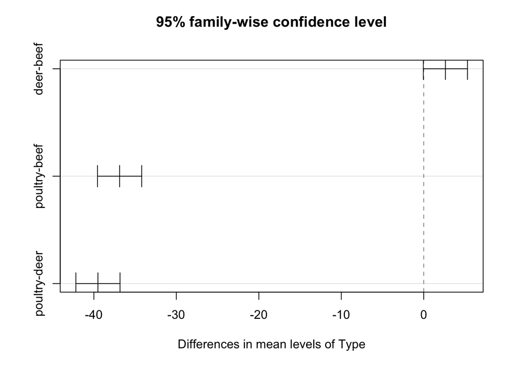

```r
plot(tukey_result)
```

**Answer**:

-From the anova result, the P-value is 2e-16 << alpha = 0.05, so we can reject null hypothesis, which means there is a significant difference in the number of calories based on the different type of hot dog.

-From Tukey’s HSD, the diff of deer-beef is 2.63, the p adj of deer-beef is 0.056 > alpha = 0.05, so we can not to reject null hypothesis, which means there is no significant difference between deer and beef.

-The diff of poultry-beef is 36.89, and the diff of poultry-deer is 39.51, the p adj of poultry-beef and poultry-deer is less than alpha = 0.05, so we can reject null hypothesis, which means there is a significant difference between poultry and beef and between poultry and deer.

# 4 Question 4

```r
data4=read.csv("data_q4.csv")
head(data4)
```

```
  sucrose weight days.old cactus.type
1     5.0  21.65       52        Wild
2     7.0  20.29       52      Blanco
3     6.0  28.61       52      Blanco
4     7.8  24.45       52      Blanco
5    10.8  34.26       53      Blanco
6     7.2  21.54       52      Blanco
```

## 4.1 A

**Answer**:

I will use a multiple linear regression model to analyze the relationship between `sucrose` levels and predictor variables, which include `weight`, `days.old`, and `cactus.type`.

## 4.2 B

```r
cor(data4[,2:3])
```

```
              weight    days.old
weight    1.00000000 -0.09902604
days.old -0.09902604  1.00000000
```

```r
vif(lm(sucrose ~ weight + days.old + cactus.type, data=data4))
```

```
                GVIF Df GVIF^(1/(2*Df))
weight      1.587287  1        1.259876
days.old    1.174890  1        1.083923
cactus.type 1.694358  3        1.091861
```

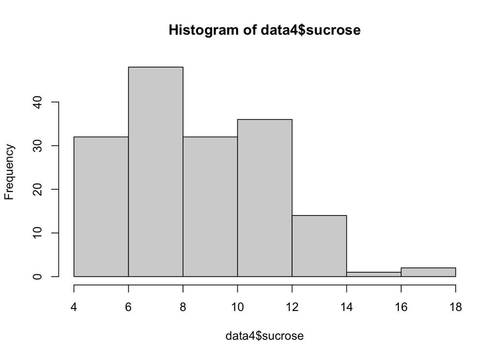

```r
hist(data4$sucrose)
```

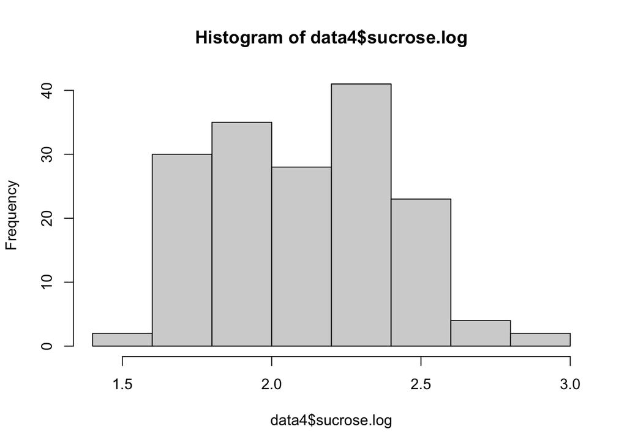

```r
data4 <- data4 %>%
  mutate(sucrose.log=log(sucrose))
hist(data4$sucrose.log)
```

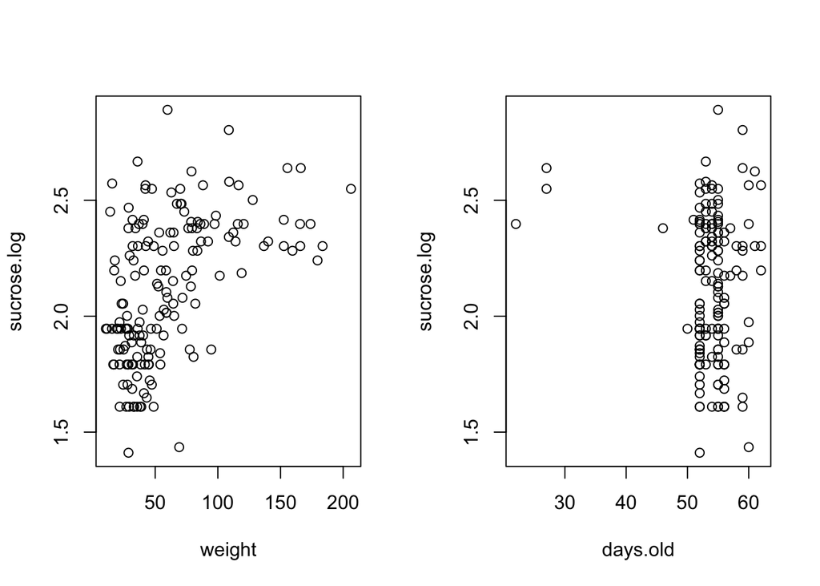

```r
lmod <- lm(sucrose.log~weight+days.old+cactus.type, data=data4)
# Linear relationship
par(mfrow=c(1,2))
plot(sucrose.log~weight, data=data4)
plot(sucrose.log~days.old, data=data4)
```

```r
# check homoscedasticity
ncvTest(lmod)
```

```
Non-constant Variance Score Test
Variance formula: ~ fitted.values
Chisquare = 0.01017772, Df = 1, p = 0.91964
```

```r
# check residual normality
shapiro.test(residuals(lmod))
```

```
    Shapiro-Wilk normality test

data:  residuals(lmod)
W = 0.99057, p-value = 0.3457
```

**Answer**:

-From the shapiro test, P-value is 0.35 > alpha = 0.05, so we can not reject null hypothesis, which it meet the assumption of normality.

-From the scatter plot, we can know `sucrose` and `weight` is a linear relationship, but `sucrose` and `days.old` is not a linear relationship.

-From VIF, we could the VIF values of the variables are all lower than the standard threshold for the existence of multicollinearity (usually 5 or 10), which indicates that the correlation between the respective variables is low and there is no serious multicollinearity problem.

## 4.3 C

```r
summary(lmod)
```

```
Call:
lm(formula = sucrose.log ~ weight + days.old + cactus.type, data = data4)

Residuals:
     Min       1Q   Median       3Q      Max
-0.67255 -0.19041  0.00752  0.17672  0.71719

Coefficients:
                       Estimate Std. Error t value Pr(>|t|)
(Intercept)            1.801065   0.251604   7.158 2.84e-11 ***
weight                 0.004866   0.000615   7.912 4.04e-13 ***
days.old               0.003099   0.004576   0.677  0.49915
cactus.typeMamey      -0.215908   0.077380  -2.790  0.00591 **
cactus.typeTenamaxtle -0.255828   0.057652  -4.437 1.69e-05 ***
cactus.typeWild       -0.089505   0.056200  -1.593  0.11323
---
Signif. codes:  0 '***' 0.001 '**' 0.01 '*' 0.05 '.' 0.1 ' ' 1

Residual standard error: 0.2537 on 159 degrees of freedom
Multiple R-squared:  0.337, Adjusted R-squared:  0.3161
F-statistic: 16.16 on 5 and 159 DF,  p-value: 7.192e-13
```

**Answer**:

-For `weight`, the p-value is 4.04e-13 < alpha = 0.05, so we can reject null hypothesis, which means there is a significant positive correlation between `weight` and `sucrose`. In other words, the heavier the fruit, the higher `sucrose` it is likely to be.

-For `days.old`, the p-value is 0.49915 > alpha = 0.05, so we can not reject null hypothesis, which means there is no significant correlation between `days.old` and `sucrose`.

-For `cactus.typeMamey`, the coefficient is -0.215908, the p-value is 0.00591 < alpha = 0.05, so we can reject null hypothesis, which means there is a significant correlation between `cactus.typeMamey` and `sucrose`, and the fruits of the Mamey variety have a significantly lower `sucrose` than those of other varieties.

-For `cactus.typeTenamaxtle`, the coefficient is -0.255828, the p-value is1.69e-05 << alpha = 0.05, so we can reject null hypothesis, which means there is a significant correlation between `cactus.typeTenamaxtle` and `sucrose`, and the fruits of the Tenamaxtle variety have a significantly lower `sucrose` than those of other varieties.

-For `cactus.typeWild`, the coefficient is -0.089505 , the p-value is 0.11323 > alpha = 0.05, so we can not reject null hypothesis, which means there is no significant correlation between `cactus.typeWild` and `sucrose`.

## 4.4 D

```r
lmod2 <- lm(sucrose.log~weight+cactus.type*days.old, data=data4)
summary(lmod2)
```

```
Call:
lm(formula = sucrose.log ~ weight + cactus.type * days.old, data = data4)

Residuals:
     Min       1Q   Median       3Q      Max
-0.67409 -0.16381 -0.00898  0.15884  0.70751

Coefficients:
                                 Estimate Std. Error t value Pr(>|t|)
(Intercept)                    -1.3501814  1.4811147  -0.912  0.36339
weight                          0.0043768  0.0006193   7.068 4.94e-11 ***
cactus.typeMamey                3.1640960  1.4915144   2.121  0.03547 *
cactus.typeTenamaxtle           5.8437690  2.1852619   2.674  0.00829 **
cactus.typeWild                -2.0786402  2.2341812  -0.930  0.35361
days.old                        0.0637145  0.0282364   2.256  0.02543 *
cactus.typeMamey:days.old      -0.0638379  0.0284725  -2.242  0.02637 *
cactus.typeTenamaxtle:days.old -0.1135201  0.0405437  -2.800  0.00576 **
cactus.typeWild:days.old        0.0367754  0.0423844   0.868  0.38691
---
Signif. codes:  0 '***' 0.001 '**' 0.01 '*' 0.05 '.' 0.1 ' ' 1

Residual standard error: 0.2428 on 156 degrees of freedom
Multiple R-squared:  0.4046,    Adjusted R-squared:  0.374
F-statistic: 13.25 on 8 and 156 DF,  p-value: 1.633e-14
```

**Answer**:

-For `days.old:cactus.typeMamey`, the slope is -0.063837, the p-value is 0.02637< alpha = 0.05, so we can reject null hypothesis, which means there is a significant correlation between `days.old:cactus.typeMamey` and `sucrose`, and as the fruit ages, the `sucrose` of the Mamey variety may decrease slightly.

-For `days.old:cactus.typeTenamaxtle`, the slope is -0.1135201, the p-value is 0.00576 < alpha = 0.05, so we can reject null hypothesis, which means there is a significant correlation between `days.old:cactus.typeTenamaxtle` and `sucrose`, and as the fruit ages, the `sucrose` of the Tenamaxtle variety may decline more significantly.

## 4.5 E

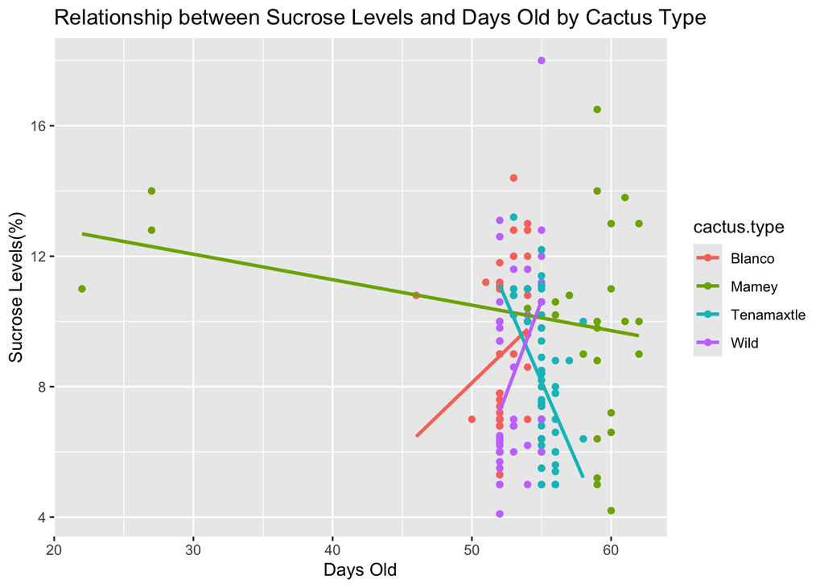

```r
library(ggplot2)
ggplot(data4, aes(x = days.old, y = sucrose, color = cactus.type)) +
  geom_point() +
  geom_smooth(method = "lm", se = FALSE) +
  labs(x = "Days Old", y = "Sucrose Levels(%)", title = "Relationship between Sucrose Levels and Days Old by Cactus Type")
```

# 5 Extra Credits

```r
library(lme4)
data(sleepstudy)
summary(sleepstudy)
```

```
    Reaction          Days        Subject
 Min.   :194.3   Min.   :0.0   308    : 10
 1st Qu.:255.4   1st Qu.:2.0   309    : 10
 Median :288.7   Median :4.5   310    : 10
 Mean   :298.5   Mean   :4.5   330    : 10
 3rd Qu.:336.8   3rd Qu.:7.0   331    : 10
 Max.   :466.4   Max.   :9.0   332    : 10
                               (Other):120
```

```r
library(Matrix)
library(lme4)
mixed_model <- lmer(Reaction ~ Days + (1 | Subject), data = sleepstudy)
summary(mixed_model)
```

```
Linear mixed model fit by REML ['lmerMod']
Formula: Reaction ~ Days + (1 | Subject)
   Data: sleepstudy

REML criterion at convergence: 1786.5

Scaled residuals:
    Min      1Q  Median      3Q     Max
-3.2257 -0.5529  0.0109  0.5188  4.2506

Random effects:
 Groups   Name        Variance Std.Dev.
 Subject  (Intercept) 1378.2   37.12
 Residual              960.5   30.99
Number of obs: 180, groups:  Subject, 18

Fixed effects:
            Estimate Std. Error t value
(Intercept) 251.4051     9.7467   25.79
Days         10.4673     0.8042   13.02

Correlation of Fixed Effects:
     (Intr)
Days -0.371
```

**Answer**:

-The results show that the estimated intercept value is 251.41, the standard error is 9.75, and the corresponding T-value is 25.79. The estimated value of Days is 10.47, the standard error is 0.80, and the corresponding T-value is 13.02, which indicats the impact of intercept and `days` on `reaction` time is significant.

-In random effects, the model takes into account the variability between different subjects. The results showed that the variance between subjects was estimated to be 1378.2 with a standard deviation of 37.12, while the residual variance was estimated to be 960.5 with a standard deviation of 30.99.